# Regresión Lineal

Pablo César Rodríguez Aguayo

April 11, 2019

Cabecera del Conjunto de Datos

| X | Y |
| --- | --- |
| 5.5277 | 9.1302 |
| 8.5186 | 13.6620 |
| 7.0032 | 11.8540 |
| 5.8598 | 6.8233 |
| 8.3829 | 11.8860 |
| 7.4764 | 4.3483 |

## Regresión Lineal

La regresión lineal se emplea como un modelo el cual permite ejemplificar la relación entre la variable dependiente y su variable independiente. Comunmente, las relaciones son modeladas utilizando funciones predictoras lineales donde sus parametros son calculados de los datos, a este tipo de modelos se les conoce como lineares.

#### Implementación de la Regresión Lineal

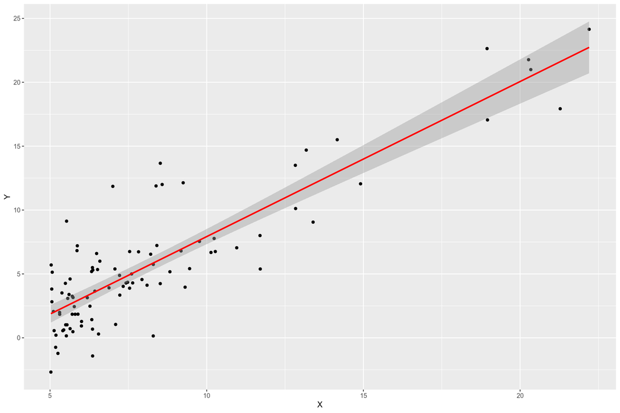

### Supuestos del Modelo de Regresión

Como se sabe, el modelo de regresión lineal ha de cumplir una serie de supuestos que garanticen su correcta aplicación:

#### **Linealidad**

Existe linealidad si se presenta una relación significativa entre la variable que se quiere predecir y las otras variables. Puede usarse el coeficiente “R cuadrado ajustado”, para saber si existe linealidad (mayor o igual a 0.7 suele ser “indicio” de linealidad).

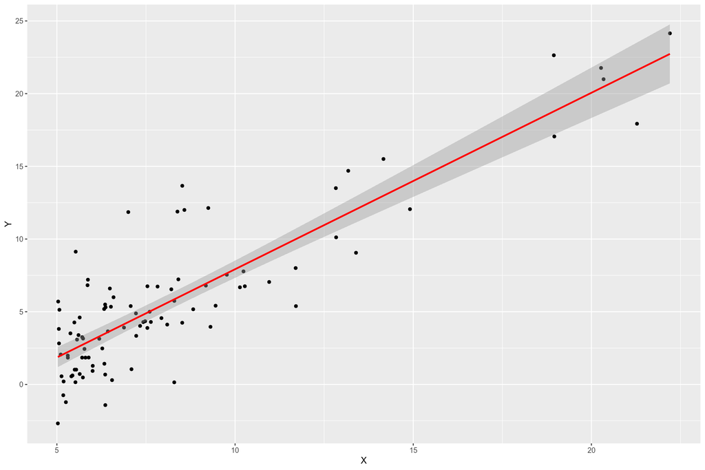

[1] “R-Cuadrado Ajustado= 0.76”

**Comentarios:** Si cumple el supuesto de linealidad ya que $R^2$ es mayor a 0.7 con un valor de. 0.76.

#### **Independencia de Errores**

Este supuesto asume que los residuos no están auto-correlacionados, por lo cual son independientes. La autocorrelacion es cuando el residuo en la predicción de un valor es afectado por el residuo en la predicción del valor más cercano. Esta autocorrelacion suele presentarse en series de tiempo. Para validar la independencia de los residuos puede usarse el test Durbin-Watson, cuyo resultado estará cerca de 2 cuando los residuos son independientes. Si el valor está entre 1.5 y 2.5 puede concluirse que no existe dependencia de los residuos.

```
  DW
```

1.199538

```
Durbin-Watson test
```

data: Y ~ . DW = 1.1995, p-value = 1.86e-05 alternative hypothesis: true autocorrelation is greater than 0

#### **Homocedasticidad**

Este supuesto asume que los residuos en las predicciones son constantes en cada predicción (es decir, varianza constante). Este supuesto valida que los residuos no aumenta ni disminuye cuando se predicen valores cada vez más altos o mas pequeños. A esta constancia en los errores de predicción le dicen “homocedasticidad”, y cuando los errores varían, le dicen *heterocedasticidad*. Para comprobar la homocedasticidad para los residuos estudentizados del modelo ajustado y contrastarla se utiliza la función *bptest()*.

```
   BP
```

0.9271893

#### **Supuesto de Normalidad de los Residuos**

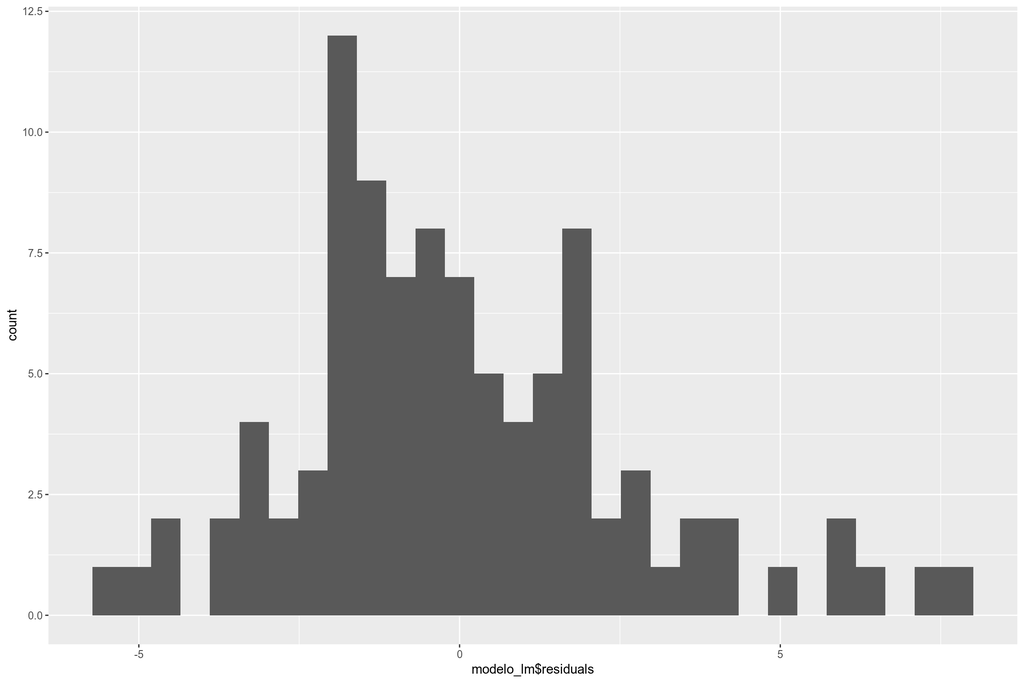

**Comentarios:** En base a la distribución anterior, se puede apreciar que no es una distribución normal. Por lo cual se asume poca precision en los intervalos de confianza creados por el modelo.